# Case Study 1 - Heliotronics : Estimating an Experience Curve

Giovanni Carta, Zahra Ghafghazi, Sophia Ropelewski

2026-03-18

## Import the data

First, the data saved in the csv file `Case_Stud_ I.csv` is imported. By inspecting the dataset, we observe that it has 22 observations and 2 variables : the manufacturing cost and the number of solar panels.

```r
# Import the data
heliotronics_data <- read.csv("Case_Stud_ I.csv", sep = ";")

# Inspect the data
print(heliotronics_data)
```

```
##    number_of_solar_panels manufacturing_cost
## 1                     100             1250.0
## 2                     200             1108.7
## 3                     300             1053.5
## 4                     400             1033.4
## 5                     500              989.8
## 6                     600              999.0
## 7                     700              914.9
## 8                     800              931.0
## 9                     900              922.3
## 10                   1000              902.9
## 11                   1100              820.9
## 12                   1200              823.2
## 13                   1300              876.7
## 14                   1400              817.2
## 15                   1500              850.2
## 16                   1600              815.3
## 17                   1700              804.6
## 18                   1800              765.3
## 19                   1900              820.6
## 20                   2000              828.1
## 21                   2100              800.2
## 22                   2200              784.5
```

```r
# Extract the two variables of interest
cost<-heliotronics_data$manufacturing_cost
n_sol_panels<- heliotronics_data$number_of_solar_panels
```

## Question 1 : Scatter plot

As a first analysis step, a scatter plot is performed on the data, as well as a smooth fitted curve using the $geom\_smooth()$ method. This provides a visual indication of the general trend followed by the data.

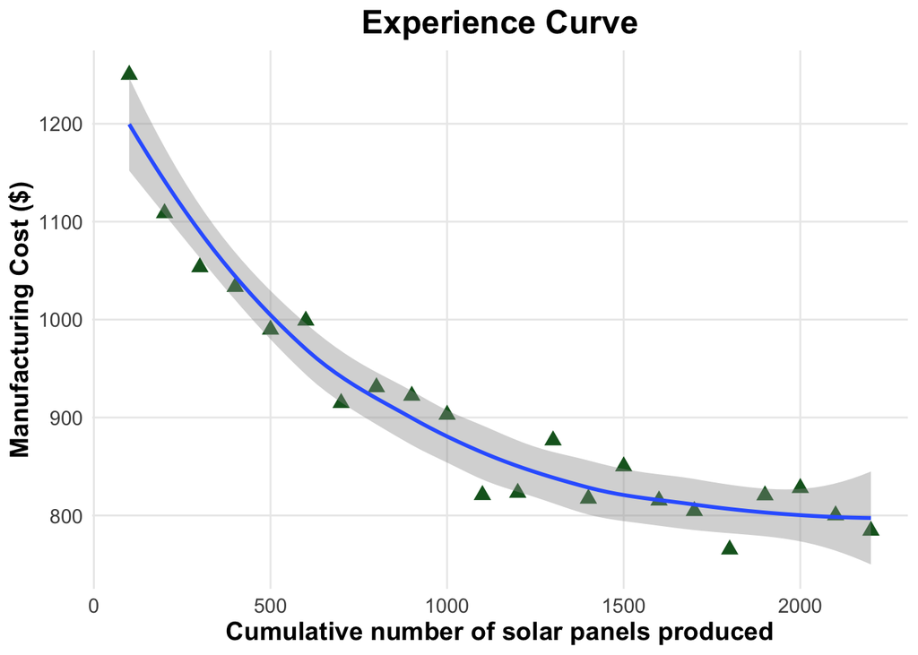

```r
library(ggplot2)
ggplot(data = data.frame(n_sol_panels, cost),
       aes(x = n_sol_panels, y = cost)) +
  geom_point(shape=17, color = "#166325", size = 3) +
  geom_smooth() +
  labs(
    title = "Experience Curve",
    x = "Cumulative number of solar panels produced",
    y = "Manufacturing Cost ($)"
  ) +
  theme_minimal() +
  theme(
    plot.title = element_text(size = 18, face = "bold", hjust = 0.5),
    axis.title = element_text(size = 14, face = "bold"),
    axis.text = element_text(size = 11),
    panel.grid.minor = element_blank()
  )
```

We are interested in studying a relationship of the form $Y = AX^b$, where Y are the average manufacturing cost of the last batch of 100 solar panels at Heliotronics in $ after having produced a cumulative production of X solar panels, b is the experience parameter, and A is cost of the first unit.

As the data is not linear, a log-log transformation is applied on it. The scatter plot is performed again on the transformed data.

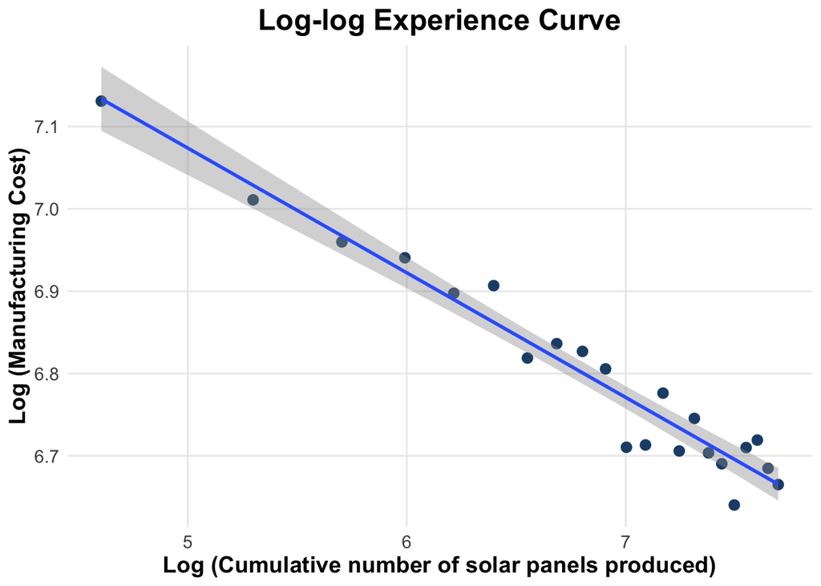

```r
# Log-log plot of the data to check linearity.

ggplot(data = data.frame(n_sol_panels, cost),
       aes(x = log(n_sol_panels), y = log(cost))) +
  geom_point(shape = 16, color = "#1f4e79", size = 3) +
  geom_smooth(method="lm")+
  labs(
    title = "Log-log Experience Curve",
    x = "Log (Cumulative number of solar panels produced)",
    y = "Log (Manufacturing Cost)"
  ) +
  theme_minimal() +
  theme(
    plot.title = element_text(size = 18, face = "bold", hjust = 0.5),
    axis.title = element_text(size = 14, face = "bold"),
    axis.text = element_text(size = 11),
    panel.grid.minor = element_blank()
  )
```

The curve seems to be indeed linear after applying the log-log transformation. We can now modelise a relationship of the form $y = a+bx$, where $a = log(A)$, $y=log(Y)=log(cost)$, and $x = log(X) = log(n\_sol\_panels)$. On the original scale, this corresponds to the experience curve $Y = AX^b$.

## Question 2 : Linear Regression and learning rate

A linear regression model for $log(cost) = a + b\ log(n\_sol\_panels)$ is estimated using the above transformed data.

```r
# Modelisation of a linear regression on the log transformed data
lin_reg <- lm(log(cost) ~ log(n_sol_panels))
summary(lin_reg)
```

```
##
## Call:
## lm(formula = log(cost) ~ log(n_sol_panels))
##
## Residuals:
##       Min        1Q    Median        3Q       Max
## -0.060046 -0.016829  0.003609  0.021684  0.044498
##
## Coefficients:
##                    Estimate Std. Error t value Pr(>|t|)
## (Intercept)        7.831179   0.054417  143.91  < 2e-16 ***
## log(n_sol_panels) -0.151467   0.007938  -19.08 2.64e-14 ***
## ---
## Signif. codes:  0 '***' 0.001 '**' 0.01 '*' 0.05 '.' 0.1 ' ' 1
##
## Residual standard error: 0.02991 on 20 degrees of freedom
## Multiple R-squared:  0.9479, Adjusted R-squared:  0.9453
## F-statistic: 364.1 on 1 and 20 DF,  p-value: 2.642e-14
```

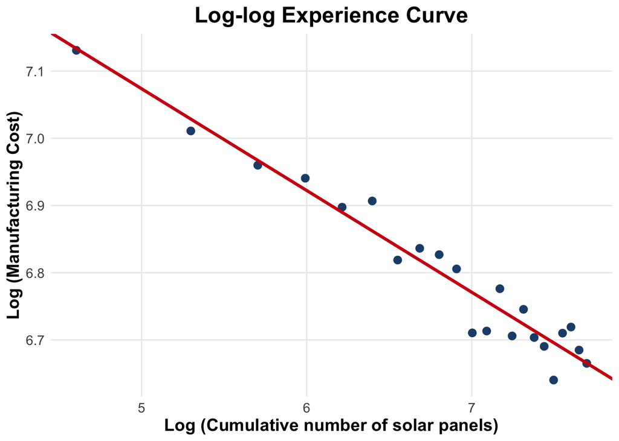

```r
a <- coef(lin_reg)[1] # intercept, e.g. production cost of the first unit
b1 <- coef(lin_reg)[2] #slope, e.g. experience parameter

# Replot the scatter plot
ggplot(data = data.frame(n_sol_panels, cost),
       aes(x = log(n_sol_panels), y = log(cost))) +
  geom_point(shape = 16, color = "#1f4e79", size = 3) +
  #geom_smooth(method = "lm", se = FALSE, color = "#d10f0f", linewidth = 1.2) +
  geom_abline(intercept = a, slope = b1,
              color = "#d10f0f", linewidth = 1.2) +
  labs(
    title = "Log-log Experience Curve",
    x = "Log (Cumulative number of solar panels)",
    y = "Log (Manufacturing Cost)"
  ) +
  theme_minimal() +
  theme(
    plot.title = element_text(size = 18, face = "bold", hjust = 0.5),
    axis.title = element_text(size = 14, face = "bold"),
    axis.text = element_text(size = 11),
    panel.grid.minor = element_blank()
  )
```

From the summary, the intercept is given by $a = 7.8312$, which means that the estimated cost of the first unit (when the cumulative production is 1) is $A = e^a \approx 2520$. The slope is given by $b = −0.151467$. We observe that the p-values are extremely small, which shows that the results are statistically significant. The R-squared, equal to 0.9479, and adjusted R-squared also show that the fit is very good.

Using the above obtained results with the regression model, we can estimate the learning rate. First, we calculate the progress ratio, given by $PR = 2^b$, where $b$ is the experience parameter. It is then possible to obtain the learning rate by calculating $LR = 1 - PR$.

```r
# Progress ratio calculation
PR <- 2^b1
paste("The progress ratio is given by", round(PR*100, digits =4), "%")
```

```
## [1] "The progress ratio is given by 90.0335 %"
```

```r
# Learning rate calculation
LR <- 1 - PR
paste("The learning rate is given by", round(LR*100, digits =4), "%")
```

```
## [1] "The learning rate is given by 9.9665 %"
```

## Question 3 : Average manufacturing cost estimation

Using the estimated curve from the regression model, an estimation of the average manufacturing cost per solar panel for the 500 produced solar panels can be computed. To do this, an estimation of the average production cost per solar panel is calculated for $X = (4600, 4700, 4800, 4900, 5000)$ units using the formula $Y = AX^b$, with $A = e^a$, where $a$ is the previously found intercept.

```r
# Target X
X <- c(4600,4700,4800,4900,5000)

# Predicted Y
Y <- exp(a)*X^b1

print(Y)
```

```
## [1] 701.8623 699.5797 697.3524 695.1779 693.0539
```

```r
paste("The average manufacturing cost per solar panel is:", mean(Y), "$")
```

```
## [1] "The average manufacturing cost per solar panel is: 697.405233138251 $"
```

The obtained average is equal to 697.4052 $.

## Question 4 : Confidence Interval

In the last question, a 95% confidence interval is calculated for the average manufacturing cost per solar panel for the panels produced for Switzerland using the lower and upper bounds of the confidence interval estimate for the experience parameter $b$. We start by getting the 95% confidence interval of $b$, then, similarly as in the previous question, we calculate $Y_{up} = AX^{b_{up}}$ and $Y_{low} = AX^{b_{low}}$. Finally, we replot the log-log experience curve, with the initial linear regression in red, and two additional linear regressions in blue, given by equations of the form $y = a + b_{up}x$ and $y = a + b_{low}x$.

```r
# 95% Confidence interval of the previous calculated linear regression model
CI=confint(lin_reg)
print(CI)
```

```
##                        2.5 %     97.5 %
## (Intercept)        7.7176674  7.9446907
## log(n_sol_panels) -0.1680242 -0.1349093
```

```r
b1_min <- CI[2,1] #lower bound slope
b1_max <- CI[2,2] #upper bound slope

# Lower mean calculation
Y_low <- exp(a)*X^b1_min
paste("The lower bound average manufacturing cost per solar panel is:", round(mean(Y_low), digits =4))
```

```
## [1] "The lower bound average manufacturing cost per solar panel is: 606.0904"
```

```r
# Upper mean calculation
Y_up <- exp(a)*X^b1_max
paste("The upper bound average manufacturing cost per solar panel is:", round(mean(Y_up), digits =4))
```

```
## [1] "The upper bound average manufacturing cost per solar panel is: 802.478"
```

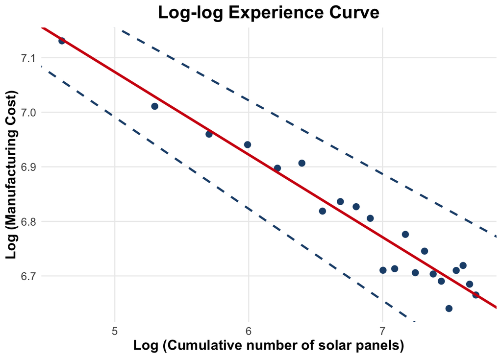

```r
# Plot of the lower and upper limits
ggplot(data = data.frame(n_sol_panels, cost),
       aes(x = log(n_sol_panels), y = log(cost))) +
  geom_point(shape = 16, color = "#1f4e79", size = 3) +
  geom_abline(intercept = a, slope = coef(lin_reg)[2],
              color = "#d10f0f", linewidth = 1.2) +
  geom_abline(intercept = a, slope = b1_min,
              color = "#1f4e79", linetype = "dashed", linewidth = 1) +
  geom_abline(intercept = a, slope = b1_max,
              color = "#1f4e79", linetype = "dashed", linewidth = 1) +
  labs(
    title = "Log-log Experience Curve",
    x = "Log (Cumulative number of solar panels)",
    y = "Log (Manufacturing Cost)"
  ) +
  theme_minimal() +
  theme(
    plot.title = element_text(size = 18, face = "bold", hjust = 0.5),
    axis.title = element_text(size = 14, face = "bold"),
    axis.text = element_text(size = 11),
    panel.grid.minor = element_blank()
  )
```